# R Basic Toturial 2015

2015-08-16

## Flow Control：程式流程控制：

## 前面把所有R的基本指令都介紹完了，

相信有不少人應該可以自豪的說：學了R以後，

[figure not shown]

## 不過……

## 那…我來幹嘛？

## 那…我來幹嘛？

放大家去吃便當!?

[figure not shown]

## 對了，

如果課程中有任何問題都可以問**助教**，  
R社群最神奇的地方就是：

[figure not shown]

**助教什麼都會!**

## 程式前言

## 程式的概念：

### 一個基本的程式，一般除了變數、資料之外 ，還有許多的指令來協助程式的完成。

## 程式的概念：

《Algorithm＋Data Structure = Programs》 by Writh

## 程式的概念：

《Algorithm＋Data Structure = Programs》 by Writh

- Data Structure: 剛剛 Ning 已經教過了，忘了要記得複習喔!

## 程式的概念：

《Algorithm＋Data Structure = Programs》 by Writh

- Data Structure: 剛剛 Ning 已經教過了，忘了要記得複習喔!
- Algorithm: 本節課程重點。實作方面分為兩大部分。
  - Control Flow
  - Function

## 程式的概念：

《Algorithm＋Data Structure = Programs》 by Writh

- Data Structure: 剛剛 Ning 已經教過了，忘了要記得複習喔!
- Algorithm: 本節課程重點。實作方面分為兩大部分。
  - Control Flow
  - Function

簡單說，寫一個程式，其實和 **寫一段文章**，或是**一篇小說**差不多， 是由取多小程式 (函數) ，根據演算法 (流程控制)，處理特定資料所組成。

## Recap

## R常用指令

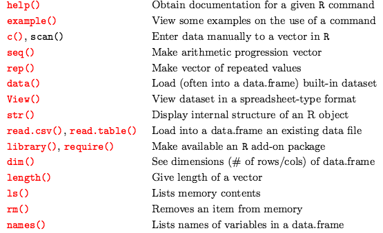

https://www.calvin.edu/~scofield/courses/m143/materials/RcmdsFromClass.pdf

## R常用指令

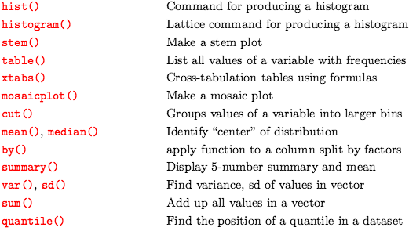

https://www.calvin.edu/~scofield/courses/m143/materials/RcmdsFromClass.pdf

## 小提醒：data.frame()

```r
num1 = c(2, 3, 5)
str1 = c("aa", "bb", "cc")
logic1 = c(TRUE, FALSE, TRUE)
(df1 = data.frame(num1, str1, logic1))
# df1 表示把 data.frame() 括號內的資料結合成為 data.frame 型態
```

```
##   num1 str1 logic1
## 1    2   aa   TRUE
## 2    3   bb  FALSE
## 3    5   cc   TRUE
```

## 比較c() vs data.frame()

```r
(df2 = c(num1, str1, logic1))
# df2 表示為 c() 括號中向量資料的結合
```

```
## [1] "2"     "3"     "5"     "aa"    "bb"    "cc"    "TRUE"  "FALSE" "TRUE"
```

## 小提醒：讀取檔案、表格：

## 讀取CSV

- CSV, Comma-separated values：逗號分隔數值
- 範例: `variable = read.csv("file_name.csv")`

```r
iris_csv = read.csv("./static/iris.csv")
View(iris_csv)
```

## 讀取 TXT

- TXT: 一般文字檔
- 範例: `variable = read.table("file_name.txt")`

```r
iris_tab = read.table("./static/iris.txt")
View(iris_tab)
```

## 讀取其他檔案 Excel

- 注意：這個需要額外的套件，請先執行：`library(gdata)`
- 範例: `variable = read.xls("file_name.xls")`

```r
library(gdata)
iris_xls = read.xls("./static/iris.xls")
View(iris_xls)
```

## 貼心小提醒：

1. 查詢指令： **?指令**
2. 查詢範例： **example(指令)**

```r
?list
example(factor)
```

## Syllabus

## Syllabus:

### 判斷條件

- `if` / `else`
- `switch`

### 迴圈

- `for`
- `while`
- `repeat` / `break`

範例：閏年計算

## Syllabus:

### Function

- 編輯撰寫一個 R 程式

### Debug and Error Handling

- 除錯（找蟲）和例外處理

## Flow Control：程式流程控制：

## if / else

### Syntex

```
if (condition_1){
    #Do something here....
} else if (conditon_2){
    #Do something here
} else {
    #Do something here
}
```

Note: **else if** and **else** are optional.

### ==> 請看 swirl 的範例

## ifelse()

### 使用方法：

ifelse(test_cond1, res_yes, res_no) 若test_cond1的條件成立（回傳是TRUE），則會執行res_yes的動作，否則test_cond1回傳是FALSE的話，則會執行res_no 例如

```r
x = 7
ifelse(x>10, print("x大於10"), print("x小於10"))
```

```
## [1] "x小於10"
## [1] "x小於10"
```

### ==> 請看 swirl 的範例

## if / else 邏輯判斷符號

- R支援的邏輯判斷符號如下：
  - `==`：等於
  - `<=`：小於等於
  - `>=`：大於等於
  - `>`：大於
  - `<`：小於
  - `!=`：不等於
  - `&`：邏輯中的「且」 或「and」
  - `|`：邏輯中的「或」 或「or」

## **if / else** 和 **ifelse()** 的差別

一般情況下，如果向量中只有一個變數時，`if / else` 和 `ifelse` 沒什麼差別， 但如果向量是一個多個數值的陣列 `array`，矩陣 `matrix`，或是 `list / data.frame` 時，這時候就很難用 `if` 來判斷了。 例如：

```r
x = c(1:10)
if (x>5)
  print("x>5")
```

## **if / else** 和 **ifelse()** 的差別

```r
x = c(1:10)
ifelse((x>5),TRUE,FALSE)
```

```
##  [1] FALSE FALSE FALSE FALSE FALSE  TRUE  TRUE  TRUE  TRUE  TRUE
```

### ==> 請看 swirl 的範例

## 那會了if，可以怎麼用？

[figure not shown]

## 小測驗：閏年

## 情境：小明的故事一

小明得到媽媽的鼓勵和更多的糖果之後，就開開心心的去學校了。 上學途中，看到滿天飛舞的櫻花，不禁心頭一陣酸楚，之前拿到的糖果此時居然愈來愈重，吃了之後也不覺得甜美。 邊走邊想著：小時候喜歡的那個女孩，也是曾經在這種爛漫的的櫻花中，含著眼淚吞著鼻水的互相告別，不知道現在怎麼樣了？ 對了，記得她是閏年出生的，那閏年的意義對她應該很重要吧。我們兩個人年紀都大了，已經不是3歲5歲的小孩了，我還能去找她嗎？還有機會嗎？還可以在一起嗎？

這時候，小明下定決心，想要認真的面對這段以前甜美，現在遺憾的回憶，打算在閏年的時候，鼓起勇氣去找她。 便在路旁的星巴八飲料店，拿出優雅的水果電腦，很快的在電腦上用R寫了一個判斷閏年的小工具。

原來如此。小明突然覺得自己很厲害

[figure not shown]

## 請判斷輸入的年份是不是閏年？

目前使用的格里曆閏年規則如下：

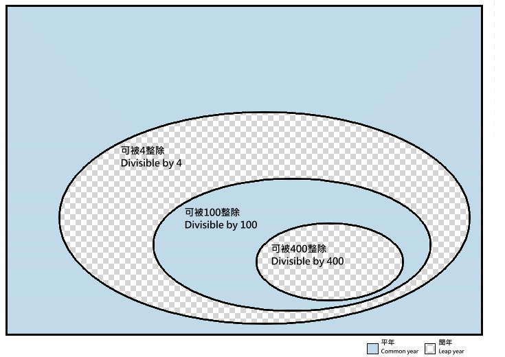

西元年份除以400可整除=閏年。  
西元年份除以4可整除但除以100不可整除=閏年。  
西元年份除以4不可整除=平年。  
西元年份除以100可整除但除以400不可整除=平年

https://zh.wikipedia.org/zh-tw/%E9%97%B0%E5%B9%B4

## case 1: if, else, %%, ==

```r
year1 = 2015  #或是可以用 as.integer(readline("input year:"))，來輸入想要的數值
if ((year1 %% 4)==0){
  if ((year1 %% 100)==0){
    if ((year1 %% 400)==0)
      print("Leap year")
    else
      print("Not leap year")
  } else {
    print("Leap year")
  }
} else {
  print("Not leap year")
}
```

```
## [1] "Not leap year"
```

```r
year1 = 2015  #或是可以用 as.integer(readline("input year:"))，來輸入想要的數值
if ( ((!(year1 %% 4)) && (year1 %%100)) || (!(year1 %% 400)) ){
  print("Leap year")
} else {
  print("Not leap year")
}
```

```
## [1] "Not leap year"
```

## 會了for，可以怎麼用？

這是copy-paste沒錯

[figure not shown]

## 小測驗2：算有多少個閏年

## 情境：小明的故事二

小明又出現了，這次他帶著更多的遺憾，更多的苦澀，回到家裡。 可是，小明他自己知道，小明這個名字是以前國立編譯館，眾多國中國小出版社，PTT八卦版許多夢境中最常被拿出來用的名字， 「小明」這兩個字充滿著正面、希望、勇氣、努力，根本就是各種可能的代名詞。連小明的日文名字：Hikari或Akira，都是史詩巨作：棋靈王主角的名字。 「我不能如此放棄」，小明如此的對自己這麼說。

這麼想的小明，腦中開始的一連串的計劃了。首先，小明第一件要做的事情，毫無疑問的就是要知道，到底有多少年是閏年。

這時候路旁的小七便利店，突然360度翻了過來，瞬間變成一家星巴八飲料店的外觀， 小七店內突然傳出聲響：Change，仔細一看，小七店員身上的招牌紅色T-Shirt，居然也變成星巴八的白衣綠裙。

天時地利人和，小明毫不猶豫的，拿起手上的水果電腦，再次走進星巴八內，誓言如果沒辦法用R寫出計算閏年的程式的話就不出來。

[figure not shown]

## 請說明輸入一段時間內（如1000~2015），有幾年是閏年？並列出分別是哪幾年？

除了上面的判斷是不是閏年之外，麻煩請在想一想，如何把一段時間內，例如從西元1000至西元2015年到底有多少年是閏年，分別為哪幾年？

提醒：可以用for來持續檢查某一年是否是閏年，例如：開始年：1000，結束年：2015

for(任意變數 in 開始:結束){ 打算要重複執行的程式 }

## case1: 使用上面的判斷式

```r
yearS = 1980 # 或是可以輸入：as.integer(readline("input start year:")) 來自己輸入開始年
yearE = 2100 # 或是可以輸入：as.integer(readline("input end year:")) 來輸入結束年
year_cnt=0
for (n in yearS:yearE){
  if ( ((!(n %% 4)) && (n %%100)) || (!(n %% 400)) ){
    year_cnt = c(year_cnt,n)
  }
}
year_cnt = year_cnt[-1]
paste("total:", length(year_cnt)," leap years")
```

```
## [1] "total: 30  leap years"
```

## case2: 使用等一下要講的函式來簡化以及方便閱讀程式

```r
is_leap_year = function(year1){
  if (((!(year1 %% 4)) && (year1 %%100)) || (!(year1 %% 400)) ){  return(TRUE)
  } else {  return(FALSE)  }
}
yearS = 1980 # 或是可以輸入：as.integer(readline("input start year:")) 來自己輸入開始年
yearE = 2100 # 或是可以輸入：as.integer(readline("input end year:")) 來輸入結束年
year_cnt=0
for (n in yearS:yearE){
  if (is_leap_year(n)){
    year_cnt = c(year_cnt,n)
    #print("year:",n)
  }
}
year_cnt = year_cnt[-1]
paste("total:", length(year_cnt)," leap years")
```

```
## [1] "total: 30  leap years"
```

## Function：函數/函式說明

## Function

Function，一般稱為函數，函式，或叫作方程式，簡單說就是把一堆為了相同目的的指令，用一個名稱綁在一起。

例如：

```r
helloworld <- function(name1){
  paste("Hello World,", name1)
}
helloworld("N")
```

```
## [1] "Hello World, N"
```

helloworld：就是函式名稱，之後要使用的話，直接在命令列上輸入helloworld()就可以了 name1：代表這個函式所帶入的參數，這邊取用name1當作參數的名字。

## Debug / Error Handling：除錯，錯誤管理

## Debug

寫了一堆程式之後，人都可能被劈腿，手一定有機會出鎚，這時候就需要一些去除錯誤（簡稱：除錯）的工具來幫忙找到錯誤。  
幸運的是，R內部就已經提供的debug() / undebug()的工具來一步一步，一行一行的找到問題。

遇到不知道怎麼使用的指令時，在console命令列中輸入?debug，變可以看到debug的說明。  
或是想知道有沒有範例可以知道某個指令怎麼用？在console命令列中輸入example(指令)，變可以看到該指令的應用

```r
?debug
```

## Error Handling

RBlogger的範例： http://www.r-bloggers.com/error-handling-in-r/

inputs = list(1, 2, 4, -5, 'oops', 0, 10)  
for(input in inputs) {  
print(paste("log of", input, "=", log(input)))  
}

很明顯的，log的參數只能接受不能輸入負數的資料，而且文字資料一定出錯，那我們要怎麼避免？

## Error Handling: 使用try()來攔截錯誤，並且讓程式繼續執行

```r
inputs = list(1, 2, 4, -5, 'oops', 0, 10)
for(input in inputs) {
  try(print(paste("log of", input, "=", log(input))))
}
```

```
## [1] "log of 1 = 0"
## [1] "log of 2 = 0.693147180559945"
## [1] "log of 4 = 1.38629436111989"
## [1] "log of -5 = NaN"
## [1] "log of 0 = -Inf"
## [1] "log of 10 = 2.30258509299405"
```

### ==> 請參考swirl範例

## Error Handling: 使用tryCatch()來顯示錯誤

```r
inputs = list(1, 2, 4, -5, 'oops', 0, 10)
for(input in inputs) {
  tryCatch(print(paste("log of", input, "=", log(input))),
  warning = function(w) {
      print(paste("negative argument", input));
      log(-input)
    },
    error = function(e) {
        print(paste("non-numeric argument", input));
        NaN})
}
```

```
## [1] "log of 1 = 0"
## [1] "log of 2 = 0.693147180559945"
## [1] "log of 4 = 1.38629436111989"
## [1] "negative argument -5"
## [1] "non-numeric argument oops"
## [1] "log of 0 = -Inf"
## [1] "log of 10 = 2.30258509299405"
```

### ==> 請參考swirl範例

## 課程預告：

### ETL (Extract, Transform and Load ) on R, by Aha

### R Visualzation : using ggplot2, by Mansun / Ben / Kyle

### R 火力展示 / 閃電秀, by c3h3